# Discus Analysis

Safari Swanson

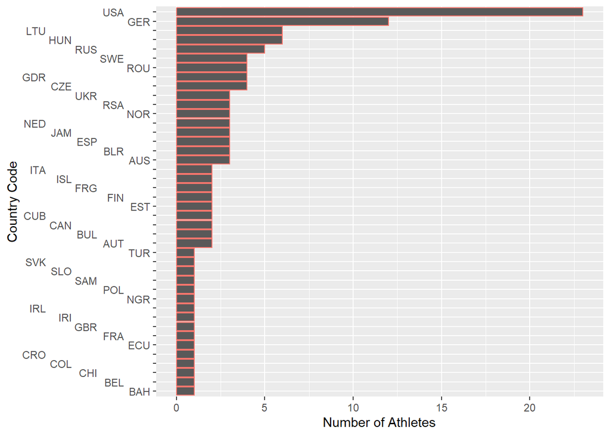

```r
#imports
library(forcats)

#Creating a dataframe with just countries and the number of athletes that came out of them
basicCountry <- MensDisc %>% distinct(Name, .keep_all = TRUE) %>% count(Country, sort = TRUE)

#Creating our barplot
ggplot(basicCountry, aes(x = fct_reorder(Country, n), y = n, color = "pink")) +
  geom_col() +
  scale_x_discrete(guide = guide_axis(n.dodge = 5)) +
  labs(y= "Number of Athletes", x = "Country Code") +
  coord_flip() +
  theme(legend.position="none")
```

This is a plot just to get a vague idea of what countries are producing the most winning athletes. It is clear that the US and Germany are far beyond the rest of the countries. With some other European states still having multiple athletes, but not as significant of a number as Germany or the US.

It is important to note that this is a generally small list of athletes so it should be kept in mind that there could be a lot of variance just caused simply by the small size of the dataset.

```r
#imports
library(lubridate)
```

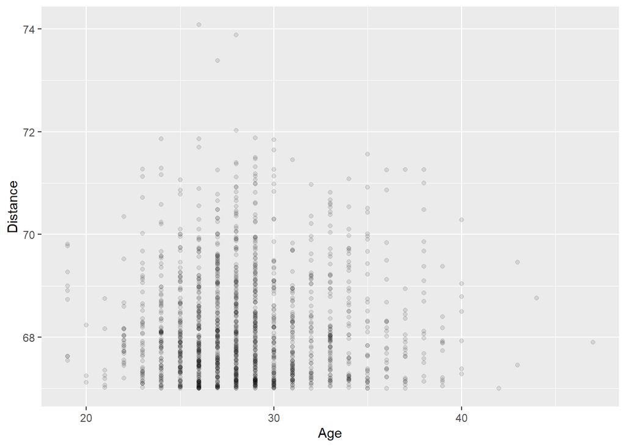

```r
ForOther <- MensDisc %>% mutate(Year = substr(Date,7,10))
Bday   <-parse_date_time2(ForOther$Birthdate, "dmy", cutoff_2000 = 15)
Rday <-parse_date_time2(ForOther$Date, "dmY", cutoff_2000 = 20)
Dif <-difftime(Rday, Bday, units = "weeks")
Please <- as.integer(Dif/52)
New <- ForOther %>%
  mutate(NewCol = Please)

#Creating a scatterplot of our athletes age's and the distances they threw at that age
ggplot(New, aes(x=NewCol, y=as.numeric(Distance))) +
  geom_point(alpha=0.1) +
  labs(y= "Distance", x = "Age")
```

From this scatter plot we can see that athletes throw the best from age 26-29, however they don’t just fall off fast. The decrease in performance seems more slow and gradual. Performance does seem to ramp up quickly when the athletes are are in their late teens and early twenties. There are almost no athletes performing at a serious level at the ages of 18, 19, and 20.

It is a very interesting point to mention that some athletes in their late thirties are still matching the distances being thrown by men nearly a decade their younger!

```r
#Imports
library(rgeos)
library(sf)
```

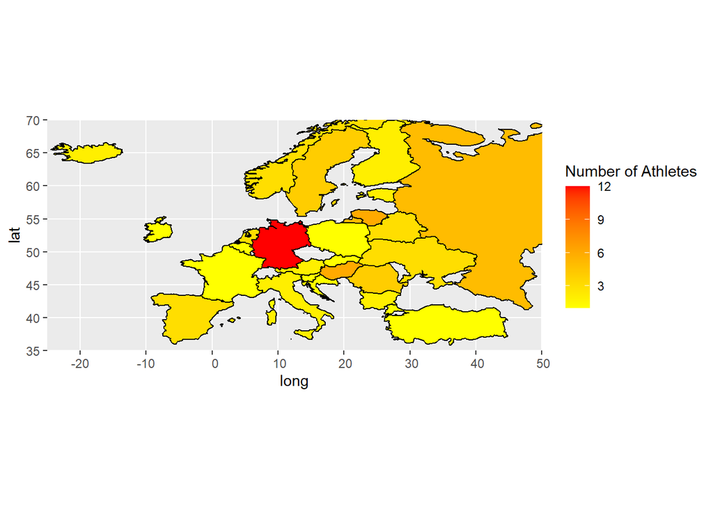

```r
library(countrycode)

#Importing country coordinates
mapData <- map_data("world")
#Converting country codes to country names to match with the coordinate vector
forMap <-basicCountry %>% mutate(region = countrycode(basicCountry$Country,"ioc","country.name"))
#Accounting for east and west germany not being covered by Countrycode library
forMap[is.na(forMap)] <- "Germany"

#Combining the coordinate dataframe with our main dataframe by region
mapData <- left_join(mapData, forMap, by="region")

#Getting rid of extra countries out of new frame
mapData1 <- mapData %>% filter(!is.na(mapData$n))
#Removing non European countries from the new frame
mapData2<-mapData1[!(mapData1$region=="United States" | mapData1$region=="Jamaica" | mapData1$region=="South Africa" | mapData1$region=="Cuba" | mapData1$region=="Bahamas" | mapData1$region=="Chile" | mapData1$region=="Ecuador" | mapData1$region=="Iran" | mapData1$region=="Nigeria" | mapData1$region=="Australia" | mapData1$region=="Canada" | mapData1$region=="Colombia"),]


#Making the map
map1 <- ggplot(mapData2, aes(x = long, y = lat, group=group)) +
  geom_polygon(aes(fill = n), color="black") +
  coord_sf(xlim = c(-25,50), ylim = c(35,70), expand = FALSE) +
  scale_fill_gradient(name = "Number of Athletes", low = "yellow", high = "red", na.value="grey50")

map1
```

The purpose behind this visualization was to explore whether there was any potential correlation between the location of the European countries producing the most athletes however as we can see there seems to be no evident pattern. However we do have a very limited number of athletes from each country so if there was more data some kind of pattern could potentially become more evident.

If I were to look further into this issue I would try and investigate the GDP of each athletes corresponding country (In the year of their record setting performance) and see if a nations wealth is a potential indicator for success at discus